# ECo 602 - Analysis of Environmental Data

## ‘hist()’

The *‘hist()’* function is used to create histogram diagrams of data. Histograms are a good choice of graphing style when general distribution of a variable is analyzed.

- The first example will show how to create a very quick, single step histogram, using the *palmerpenguins* data set:

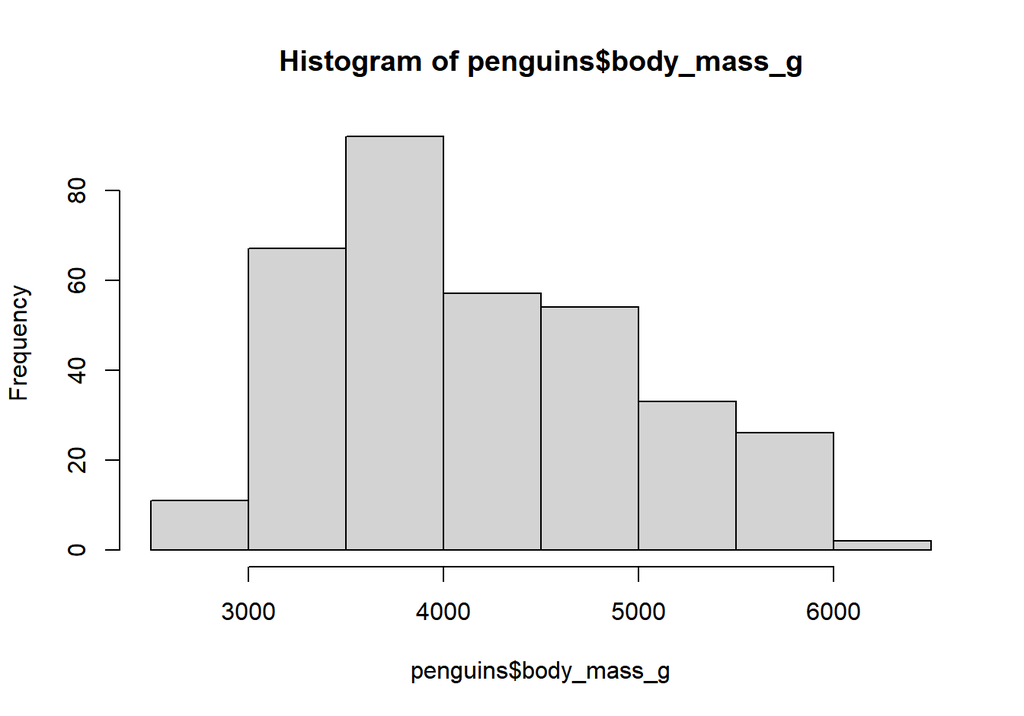

```r
hist(penguins$body_mass_g) # Specify data set and one variable which to graph. Histograms indicate specified variable in the x coordinate and frequency (or count) as default in the y coordinate. If frequency is set to FALSE, the y coordinate graphs density.
```

- The second example illustrates a more developed histogram of the same data:

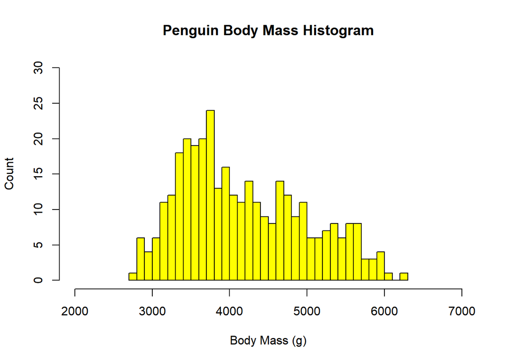

```r
hist(penguins$body_mass_g,
     breaks = 50, # Designates the number of breaks between bars along the x axis. This may provide a more detailed variation for the numerical trend of the graph.
     main = "Penguin Body Mass Histogram", #Specify the title of the graph
     xlab = "Body Mass (g)",# Specify name of the x coordinate
     ylab = "Count", # Specify name of the y coordinate
     col = "yellow", # Specify color
     xlim = c(2000,7000), # Adjusts the x coordinate limit
     ylim = c(0, 30)) # Adjusts the y coordinate limit
```

- Additionally, histograms can be used to develop density plots, which are curve representations of the variations in data.

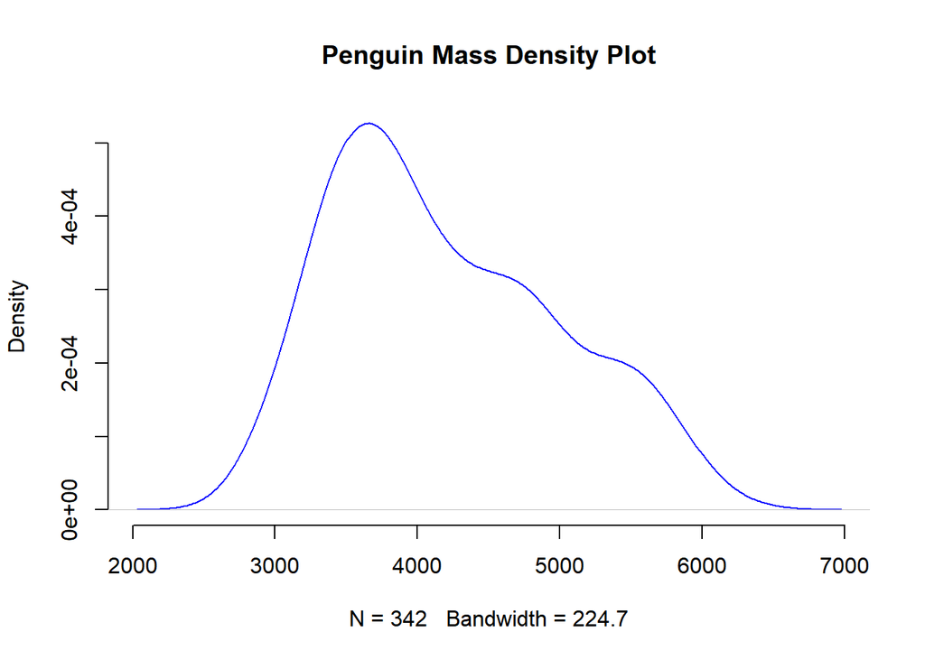

```r
plot(density
     (penguins$body_mass_g, # Specify data set and one variable which to graph.
       na.rm = TRUE), #Inform R to remove the NA value before computing the mean for the curve.
     main = "Penguin Mass Density Plot", #Specify the title of the graph
     col = "blue", #Specify the color
     frame = FALSE) #Specify no box frame
```

## ‘boxplot()’

The *‘box()’* function is used to create box plot diagrams of data. This type of graphical mapping shows the shape of data distribution, its central value indicated by the black bar, and also its variability indicated by the lowermost and uppermost boundaries of the box. Additionally, boxplots can compare several sets of data in a single representation of data, which is why they are very useful.

- The first example of the box plot will illustrate a very simple, single variable analysis. Using the *palmerpenguins* data set, we will graph penguin body mass conditioned on a single variables: species.

```r
summary(penguins) # Print summary of specified data set to see which variables may be of interest to graphically analyze.
```

```
##       species          island    bill_length_mm  bill_depth_mm
##  Adelie   :152   Biscoe   :168   Min.   :32.10   Min.   :13.10
##  Chinstrap: 68   Dream    :124   1st Qu.:39.23   1st Qu.:15.60
##  Gentoo   :124   Torgersen: 52   Median :44.45   Median :17.30
##                                  Mean   :43.92   Mean   :17.15
##                                  3rd Qu.:48.50   3rd Qu.:18.70
##                                  Max.   :59.60   Max.   :21.50
##                                  NA's   :2       NA's   :2
##  flipper_length_mm  body_mass_g       sex           year
##  Min.   :172.0     Min.   :2700   female:165   Min.   :2007
##  1st Qu.:190.0     1st Qu.:3550   male  :168   1st Qu.:2007
##  Median :197.0     Median :4050   NA's  : 11   Median :2008
##  Mean   :200.9     Mean   :4202                Mean   :2008
##  3rd Qu.:213.0     3rd Qu.:4750                3rd Qu.:2009
##  Max.   :231.0     Max.   :6300                Max.   :2009
##  NA's   :2         NA's   :2
```

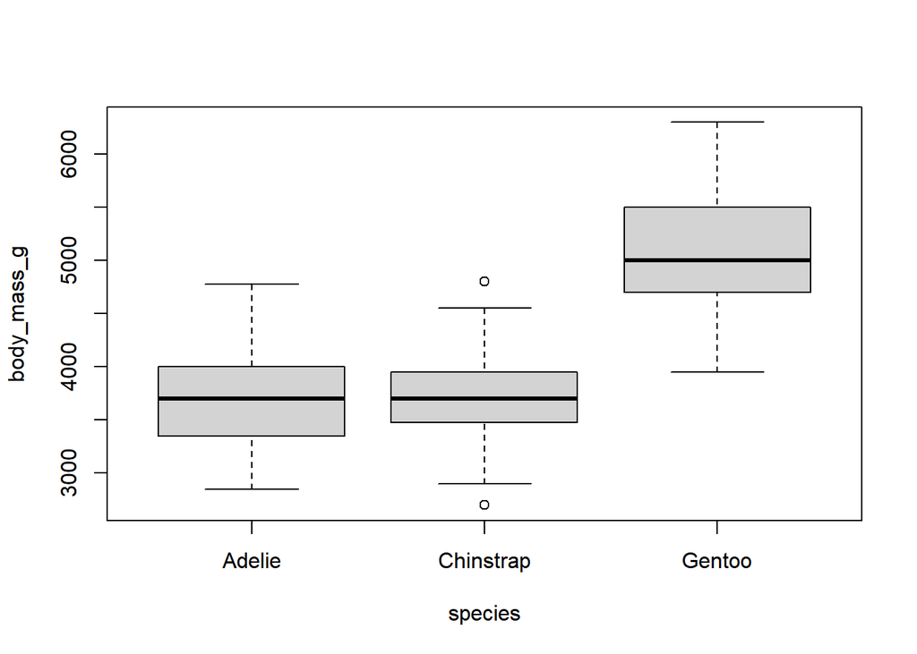

```r
boxplot(body_mass_g~species, # Specify two variables.
        data = penguins) # Specify data set.
```

- The second example is of a *conditional* box plot, which illustrates several variables for analysis. Using the *palmerpenguins* data set, we will graph penguin body mass conditioned on two variables: species and sex.

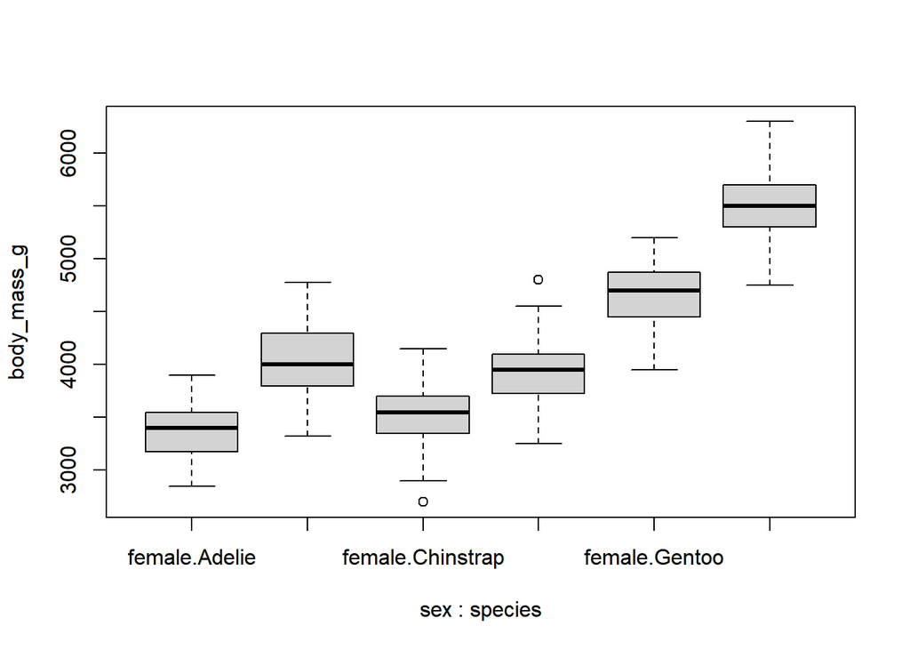

```r
boxplot(body_mass_g ~ sex * species, # Specify three variables.
        data = penguins) # Specify data set.
```

- Some additional scripts that can be used with box plots to enhance the representation of data:

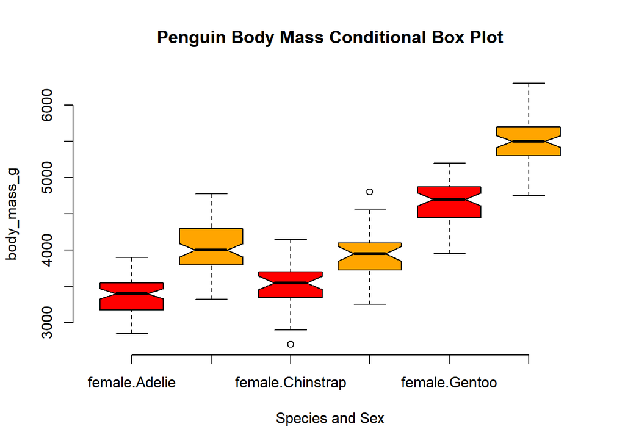

```r
boxplot(body_mass_g ~ sex * species, # Specify three variables.
        data = penguins, # Specify data set.
        main = "Penguin Body Mass Conditional Box Plot", # Specify title.
        xlab = "Species and Sex", # Specify conditional variables.
        frame = FALSE, # Specify no box frame of graph, otherwise TRUE as default
        notch = TRUE, # Specify notch, otherwise FALSE as default; helps strongly visualize the mean
        col = (c("red", "orange"))) # Specify colors.
```

## ‘par()’

The *‘par()’ function tiles several graphs into a single graphical representation.

- Including the mfrow=c(nrows, ncols) to create a matrix of nrows (number of rows) by ncols (number of columns) plots that are filled in by row. Otherwise, including mfcol=c(nrows, ncols) fills in the matrix by columns.

# Functions 4: Distribution Functions

## ‘dnorm()’

## ‘pnorm()’

## ‘dnorm()’

## ‘qnorm()’

## ‘dbinom()’

## ‘pbinom()’

## ‘qbinom()’

# Functions 5: Other Functions

## ‘subset()’

## ‘libary() and require()’

## ‘read.csv()’

The read function can be used to tell R where to locate the data file for analysis.

# Part 2: Data Anaylsis